# Factors Affecting EV Adoption in the U.S.

H.Nataraj, A.Patankar, P.Tiwari, P.Wavre

21 April 2025

## Introduction

Electric vehicles (EVs) are rapidly transforming the U.S. transportation landscape, driven by growing concerns over climate change, rising fuel prices, and supportive policy incentives. As the market expands, understanding the factors that are influencing the adoption of EVs is critical for designing equitable and effective transportation policies.

## Background

The global transition toward EVs is accelerating, driven by government policies, technological advancements, and increasing environmental awareness. Alongside these developments, fueling infrastructure in the U.S. continues to play a critical role, both in supporting traditional internal combustion engine (ICE) vehicles and facilitating the growth of the EV market. Additionally, as EVs remain relatively new and expensive technology, areas with higher purchasing power, larger populations, and greater access to charging infrastructure may experience faster and more substantial adoption rates.

## Motivation

Analyzing the relationship between EV sales trends and fuel station infrastructure is essential for effective infrastructure planning, informed policymaking, and targeted investment strategies. As EV adoption accelerates, the demand for traditional gas stations is expected to decline, accompanied by a corresponding rise in the need for robust EV charging infrastructure. Understanding these evolving trends can guide strategic decisions on how the U.S. can best adapt its fueling networks to support the clean energy transition. Furthermore, examining demographic factors such as population density and income levels can help determine optimal locations for deploying EV charging stations.

## Information on Datasets

We used five primary datasets in this analysis:

| Dataset | Source | Years |
| --- | --- | --- |
| Vehicle Registration Counts | [Alternative Fuels Data Center](https://afdc.energy.gov/vehicle-registration) | 2016–2023 |
| Average Income by State | Bureau of Economic Analysis | 2016–2023 |
| Population | [U.S. Census Bureau](https://www.census.gov/data/tables/time-series/demo/popest/2020s-state-total.html) | 2020–2024 |
| Alternative Fueling Station Counts | [Alternative Fuels Data Center](https://afdc.energy.gov/stations/states) | 2016-2023 |
| Cartographic Boundary Shapefiles | [U.S. Census Bureau](https://www.census.gov/geographies/mapping-files/time-series/geo/carto-boundary-file.html) | NA |

## Setting up the Session

```r
#Installing and loading packages
#install.packages("ggforce")
#install.packages("readxl")
library(tidyverse)
library(lubridate)
library(here)
library(ggplot2)
library(stringr)
library(cowplot)
library(ggforce)
library(scales)
library(dplyr)
library(readxl)
library(purrr)
library(broom)
library(sf)
library(leaflet)
library(mapview); mapviewOptions(fgb = FALSE)

#Check working directory
here()
```

## Importing and Cleaning Datasets

```r
#1. EV Registration Data
LDV_Data <- read_excel("Data/Raw/2016-2023 LDV Registration Data.xlsx")

#Renaming columns
colnames(LDV_Data) [c(3,4)] <- c("EV", "PHEV")

#Selecting and creating columns
LDV_Clean <- LDV_Data %>%
  mutate(Total_EV = EV + PHEV) %>%
  select(Year, State, Total_EV, EV, PHEV)

#write.csv(LDV_Clean, "Data/Processed/LDV_Clean.csv", row.names = FALSE)

#2. Income Data
Income_Data <- read.csv("Data/Raw/Average Income Data by State.csv")

#Cleaning data
Income_Clean <- Income_Data %>%
  mutate(State = str_trim(str_remove(State, "\\*"))) %>%
  rename("Avg_Income" = "Per.capita.personal.income..dollars.")

#3. Population Data
Pop_Data <- read_excel("Data/Raw/Population 2020-2024.xlsx")

#Renaming the columns
colnames(Pop_Data) [c(2,3,4,5)] <- c("Pop_2020","Pop_2021","Pop_2022","Pop_2023")

#Wrangling the data
Pop_Clean <- Pop_Data %>%
  pivot_longer(cols = starts_with("Pop_"), names_to = "Year", names_prefix = "Pop_", values_to = "Population") %>%
  select(Year, State, Population) %>%
  mutate(Year = as.numeric(Year))

#write.csv(Pop_clean, "Data/Processed/Population_Clean.csv", row.names = FALSE)

#4. Fuel Stations
Fuel_Stations <- read.csv(file = here("Data/Raw/Fuel_Stations_Historical_Data.csv"),
stringsAsFactors = TRUE)

#Selecting columns
Fuel_Stations <- Fuel_Stations[, c("Station.Name", "State", "Latitude", "Longitude", "Open.Date")]

#Formatting dates
Fuel_Stations$Open.Date <- dmy(Fuel_Stations$Open.Date)
Fuel_Stations$Open.Date <- year(Fuel_Stations$Open.Date)
Fuel_Stations <- subset(Fuel_Stations, Open.Date >= 2016 & Open.Date <= 2023)

#Converting acronyms to state names
Fuel_Stations$State <- toupper(trimws(Fuel_Stations$State))

state_abbr <- state.abb
state_names <- state.name

state_abbr <- c(state_abbr, "DC")
state_names <- c(state_names, "District of Columbia") #Added DC manually

Fuel_Stations$State <- state_names[match(Fuel_Stations$State, state_abbr)]

#Regrouping the stations
Fuel_Stations_Summary <- Fuel_Stations %>%
  group_by(Open.Date, State) %>%
  summarise(Number_of_Stations = n(), .groups = 'drop') %>%
  rename(Year = Open.Date)

#write.csv(Fuel_Stations_Summary, "Data/Processed/Fuel_Stations_Summary.csv", row.names = FALSE)

#5. Data for Maps
States_sf <- st_read( here('Data/Raw/cb_2018_us_state_5m/cb_2018_us_state_5m.shp'))
Stations_Data <- read.csv(file = here("Data/Raw/Fuel_Stations_Historical_Data.csv"),
stringsAsFactors = TRUE)
```

## Analysis 0: Visualizing Data through Graphs

### Summary Plots for EV Registration Data

In the following plots, we visualize the growth of EV registrations year-on-year from 2016-2023 for all U.S. States. We also plot the graph three times, first with all States on the same plot, second with all states except California and third, only California. California has the highest EV registrations and the plot without California aids in better visualization for other states.

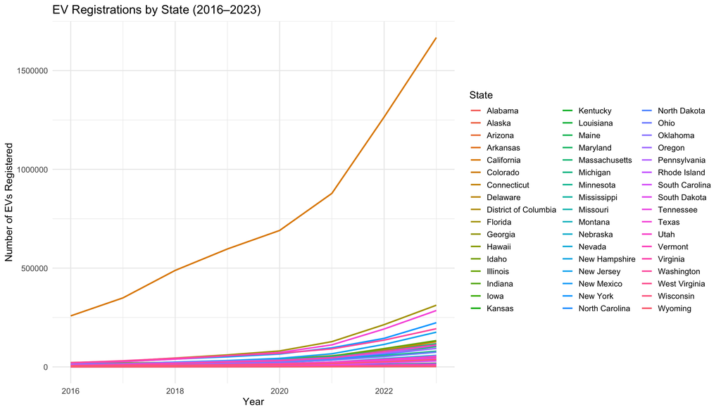

```r
#Plots of EV registrations
ggplot(LDV_Clean, aes(x = Year, y = `Total_EV`, color = State)) +
  geom_line(size = 1) +
  labs(
    title = "EV Registrations by State (2016–2023)",
    x = "Year",
    y = "Number of EVs Registered",
    color = "State"
  ) +
  theme_minimal(base_size = 14)
```

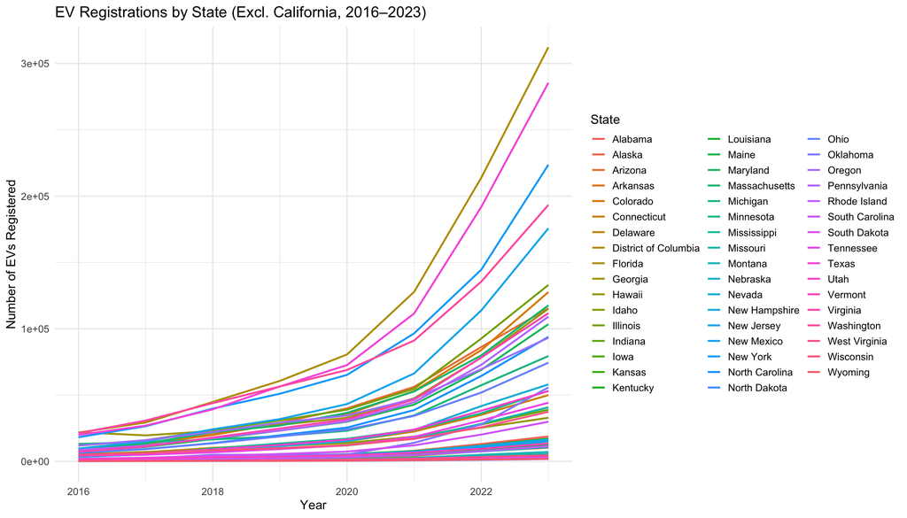

```r
#Filtering the dataset for California
LDV_Clean %>%
  filter(State != "California") %>%
  ggplot(aes(x = Year, y = `Total_EV`, color = State)) +
  geom_line(size = 1) +
  labs(
    title = "EV Registrations by State (Excl. California, 2016–2023)",
    x = "Year",
    y = "Number of EVs Registered",
    color = "State"
  ) +
  theme_minimal(base_size = 14)
```

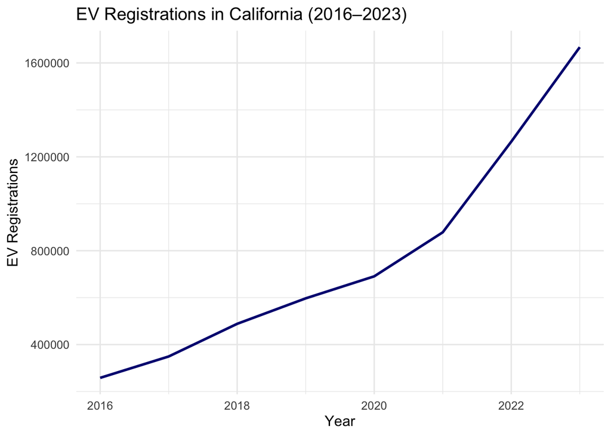

```r
#Plotting California separately
ggplot(filter(LDV_Clean, State == "California"),
       aes(x = Year, y = `Total_EV`)) +
  geom_line(color = "navy", size = 1) +
  labs(
    title = "EV Registrations in California (2016–2023)",
    x = "Year", y = "EV Registrations"
  ) +
  theme_minimal(base_size = 12)
```

> Analysis: We can see that California has the highest number of EV registrations followed by Florida.

### Maps for Charging Stations Data

#### Map of Mainland U.S., Alaska, and Hawaii

In this section we create a map of all the charging stations in U.S. The first plot includes Mainland U.S., Alaska and Hawaii.

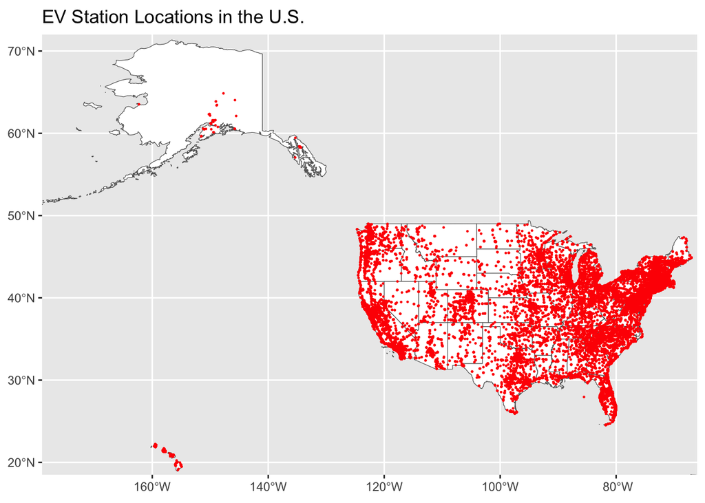

```r
#Defining boundaries and cropping territories
bbox_us <- st_bbox(c(xmin = -179, xmax = -66, ymin = 18.5, ymax = 72), crs = st_crs(States_sf))
States_sf_cropped <- st_crop(States_sf, bbox_us)

#Setting mapview preferences
mapviewOptions(basemaps = "OpenStreetMap")
#mapview(States_sf_cropped)

#Selecting required columns and removing rows which do not have valid latitude and longitude data
Stations_Map <- Stations_Data %>%
  filter(Fuel.Type.Code == "ELEC") %>%
  select(Fuel.Type.Code, Latitude, Longitude) %>%
  filter(
    !is.na(Longitude), !is.na(Latitude),
    Latitude >= 18.5, Latitude <= 72,
    Longitude <= -66, Longitude >= -179)

#write.csv(Stations_Map, "Data/Processed/EVStation_Locations.csv", row.names = FALSE)

#Converting data
Stations.sf <- Stations_Map %>%
  st_as_sf(
    coords = c('Longitude','Latitude'),
    crs=4269)

#Mapping the data
Plot_EVStationLocations <- ggplot()+
  geom_sf(data = States_sf, fill="white", size = 0.5) +
  geom_sf(data = Stations.sf, color = "red", size = 0.2)+
  ggtitle("EV Station Locations in the U.S.")+
  coord_sf(
    xlim = c(-179, -66),
    ylim = c(18.5, 72),
    expand = FALSE)
Plot_EVStationLocations
```

#### Map of Mainland U.S. only

In the second plot, we only show Mainland U.S. for better visualization.

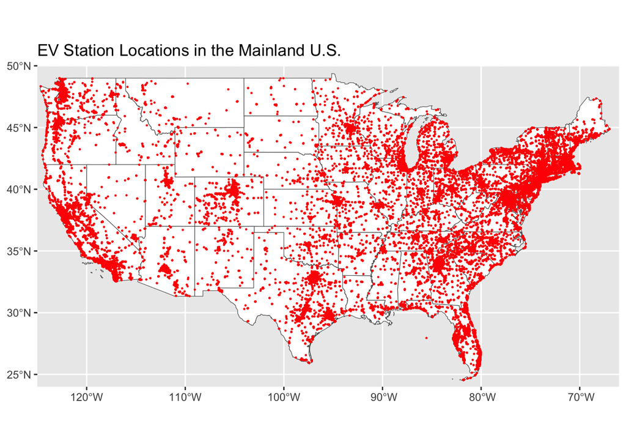

```r
#Defining boundaries and cropping territories
bbox_us2 <- st_bbox(c(xmin = -125, xmax = -66, ymin = 24, ymax = 50), crs = st_crs(States_sf))
States_sf_cropped2 <- st_crop(States_sf, bbox_us2)
#mapview(States_sf_cropped2)

#Selecting required columns and removing rows which do not have valid latitude and longitude data
Mainland_Map <- Stations_Data %>%
  filter(Fuel.Type.Code == "ELEC") %>%
  select(Fuel.Type.Code, Latitude, Longitude) %>%
  filter(
    !is.na(Longitude), !is.na(Latitude),
    Latitude >= 24, Latitude <= 50,
    Longitude <= -66, Longitude >= -125)

#Converting data
Stations.sf2 <- Mainland_Map %>%
  st_as_sf(
    coords = c('Longitude','Latitude'),
    crs=4269)

#Mapping the data
Plot_EVStationLocations2 <- ggplot()+
  geom_sf(data = States_sf, fill="white", size = 0.5) +
  geom_sf(data = Stations.sf2, color = "red", size = 0.2)+
  ggtitle("EV Station Locations in the Mainland U.S.")+
  coord_sf(
    xlim = c(-125, -66),
    ylim = c(24, 50),
    expand = FALSE)
Plot_EVStationLocations2
```

> Analysis: We see that North East U.S. and U.S. West Coast have a high density of EV charging stations. Hawaii being a decarbonization-forward state also has EV charging stations. However, Alaska has very few stations. Central U.S. and Mid-west areas of U.S. have sparse density of EV charging stations. We also see that cities have a higher concentration of stations, this might be due to cities having higher income/population which may lead to higher EV penetration.

## Analysis 1: Effect of Various Factors on EV Sales

### Number of EVs vs Number of Charging Stations

In this part of our analysis, we explore whether the number of charging stations in a state is correlated to the number of electric vehicles sold in that state. To do so, we will start by cleaning our data, conducting a correlation test, and then creating a scatter plot with a linear regression line.

```r
#Wrangling data
Station_vs_EV <- left_join(
  Fuel_Stations_Summary, LDV_Clean, by = c("Year", "State"))
Cleaned_EV_Station_Data <- Station_vs_EV %>%
  filter(!is.na(Total_EV), !is.na(Number_of_Stations))

#Correlation test
Station.test <- cor.test(Cleaned_EV_Station_Data$Total_EV, Cleaned_EV_Station_Data$Number_of_Stations)
Station.test
```

```
##
##  Pearson's product-moment correlation
##
## data:  Cleaned_EV_Station_Data$Total_EV and Cleaned_EV_Station_Data$Number_of_Stations
## t = 26.975, df = 403, p-value < 2.2e-16
## alternative hypothesis: true correlation is not equal to 0
## 95 percent confidence interval:
##  0.7645495 0.8344409
## sample estimates:
##      cor
## 0.802227
```

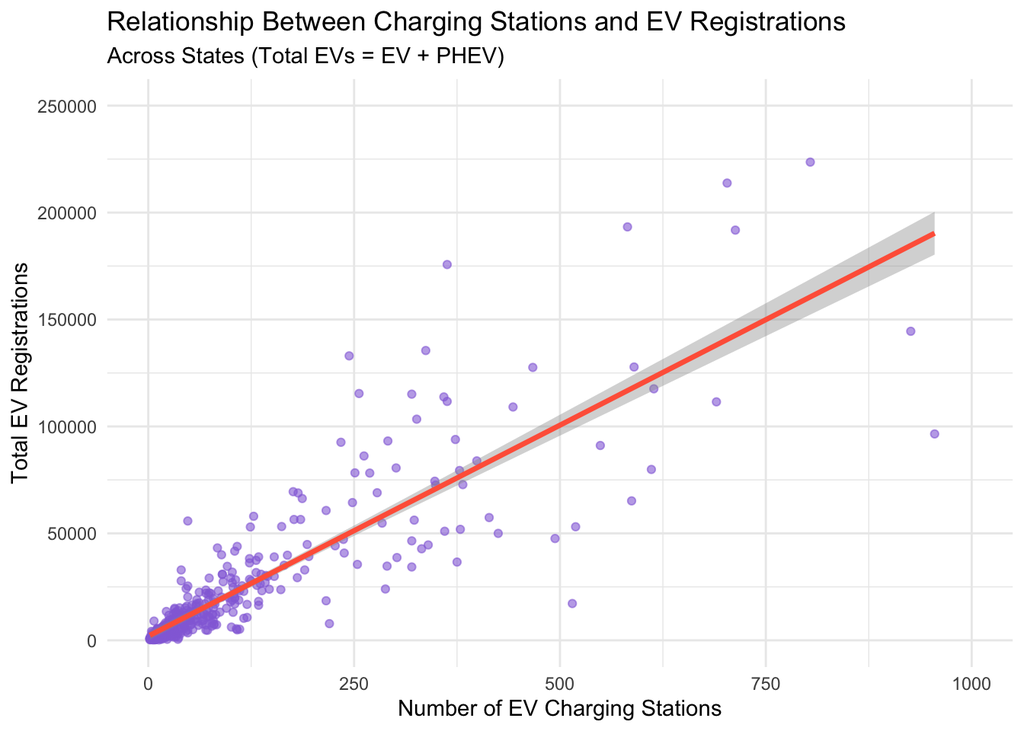

```r
#Plotting the data
ggplot(Cleaned_EV_Station_Data, aes(x = Number_of_Stations, y = Total_EV)) +
  geom_point(alpha = 0.6, color = "mediumpurple") +
  geom_smooth(method = "lm", se = TRUE, color = "tomato", linewidth = 1.2) +
  labs(
    title = "Relationship Between Charging Stations and EV Registrations",
    subtitle = "Across States (Total EVs = EV + PHEV)",
    x = "Number of EV Charging Stations",
    y = "Total EV Registrations"
  ) +
  ylim(0,250000) +
  xlim(0, 1000) +
  theme_minimal()
```

> Analysis: The correlation test reveals a strong positive relationship between the number of EV charging stations and the number of EV registrations across states (r = 0.80, p < 2.2e-16). This suggests that as the number of available charging stations increases, EV adoption also rises significantly. The strength of this correlation indicates that infrastructure availability may be a key enabler in encouraging EV uptake.

### Number of EVs vs Average income of States

In this part of our analysis, we explore whether the average income of a state is correlated to the number of electric vehicles sold in that state. To do so, we will start by cleaning our data, conducting a correlation test, and then creating a scatter plot with a linear regression line.

```r
#Wrangling Data
EV_vs_Income <- left_join(LDV_Clean, Income_Clean, by = c("State", "Year"))

#Correlation test
EV.test <- cor.test(EV_vs_Income$Total_EV, EV_vs_Income$Avg_Income)
EV.test
```

```
##
##  Pearson's product-moment correlation
##
## data:  EV_vs_Income$Total_EV and EV_vs_Income$Avg_Income
## t = 5.9825, df = 406, p-value = 4.827e-09
## alternative hypothesis: true correlation is not equal to 0
## 95 percent confidence interval:
##  0.1928718 0.3714473
## sample estimates:
##       cor
## 0.2846268
```

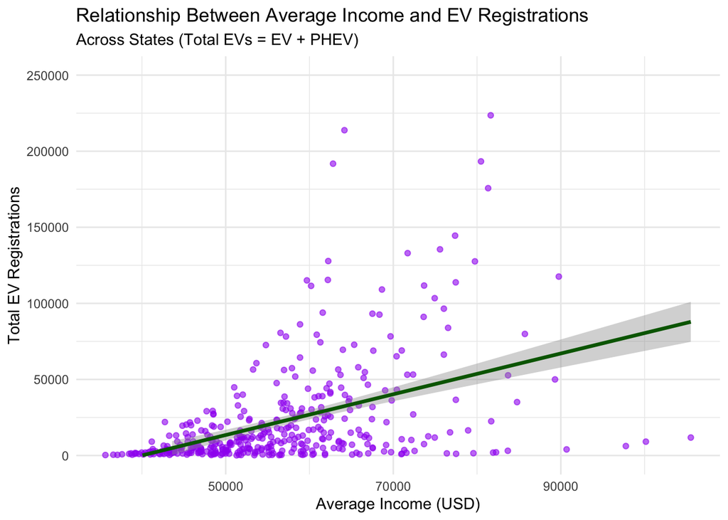

```r
#Plotting the data
ggplot(EV_vs_Income, aes(x = Avg_Income, y = Total_EV)) +
  geom_point(alpha = 0.6, color = "purple") +
  geom_smooth(method = "lm", se = TRUE, color = "darkgreen", linewidth = 1.2) +
  labs(
    title = "Relationship Between Average Income and EV Registrations",
    subtitle = "Across States (Total EVs = EV + PHEV)",
    x = "Average Income (USD)",
    y = "Total EV Registrations"
  ) +
  ylim(0,250000) +
  theme_minimal()
```

> Analysis: We observe a moderate positive correlation between average income and EV registrations, with a Pearson correlation coefficient of 0.28 (p ≈ 4.83e-09). Although not as strong as the population relationship, this still indicates that higher-income states are more likely to have greater EV uptake. This aligns with expectations, as electric vehicles are often priced higher than conventional cars, and wealthier populations may have more disposable income and access to incentives for EV purchases.

### Number of EVs vs Population of States

In this part of our analysis, we explore whether the population of a state is correlated to the number of electric vehicles sold in that state. To do so, we will start by cleaning our data, conducting a correlation test, and then creating a scatter plot with a linear regression line.

```r
#Wrangling Data
EV_vs_Pop <- left_join(LDV_Clean, Pop_Clean, by = c("Year", "State"))

#Correlation test
Pop.test <- cor.test(EV_vs_Pop$Total_EV, EV_vs_Pop$Population)
Pop.test
```

```
##
##  Pearson's product-moment correlation
##
## data:  EV_vs_Pop$Total_EV and EV_vs_Pop$Population
## t = 15.667, df = 202, p-value < 2.2e-16
## alternative hypothesis: true correlation is not equal to 0
## 95 percent confidence interval:
##  0.6715981 0.7969289
## sample estimates:
##       cor
## 0.7406392
```

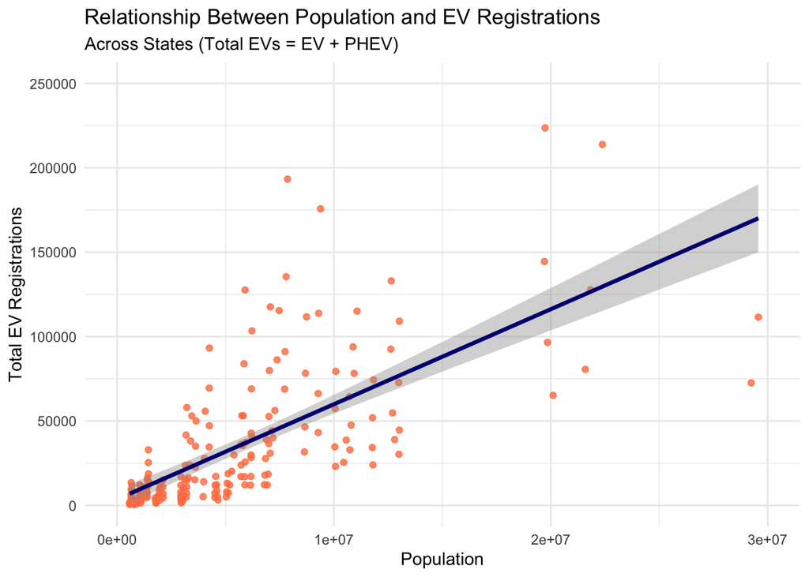

```r
#Plotting the data
ggplot(EV_vs_Pop, aes(x = Population, y = Total_EV)) +
  geom_point(alpha = 0.8, color = "coral") +
  geom_smooth(method = "lm", se = TRUE, color = "navy", linewidth = 1.2) +
  labs(
    title = "Relationship Between Population and EV Registrations",
    subtitle = "Across States (Total EVs = EV + PHEV)",
    x = "Population",
    y = "Total EV Registrations"
  ) +
   ylim(0,250000) +
  xlim(0,30000000) +
  theme_minimal()
```

> Analysis: We can see that there is a strong positive relationship between a state’s population and the number of EV registrations. This is supported by the Pearson correlation coefficient of 0.74 (p < 2.2e-16), suggesting that as population increases, EV registrations tend to rise proportionally. The trendline in the scatterplot confirms this upward trend, indicating that more populous states tend to have significantly higher EV adoption levels—likely due to larger urban areas, better infrastructure, and broader consumer bases.

## Analysis 2: Predicting the Number of EV Stations based on EV Sales

### Linear Regression Analysis

In this analysis, we predict the number of EV registrations and EV charging stations from year 2024 to 2026 for all U.S. states. We have data availability for state-wise EV registrations till 2023. We perform linear regression modeling on the historic data of EV registrations and number of charging stations to make the predictions.

```r
#Projecting EV growth for 2024–2026 using LM
EV_Projections_By_State <- Cleaned_EV_Station_Data %>%
  group_by(State) %>%
  do({
    ev_model <- lm(Total_EV ~ Year, data = .)
    future_years <- data.frame(Year = 2024:2026)
    predicted_evs <- round(predict(ev_model, newdata = future_years))
    data.frame(State = unique(.$State), Year = future_years$Year, Total_EV = predicted_evs)
  }) %>%
  ungroup()

#Cleaning duplicates
EV_Projections_By_State <- EV_Projections_By_State %>%
  distinct(State, Year, .keep_all = TRUE)

#Predicting required stations based on projected EV counts
Station_Predictions_By_State <- Cleaned_EV_Station_Data %>%
  group_by(State) %>%
  nest() %>%
  left_join(
    EV_Projections_By_State %>% group_by(State) %>% nest(.key = "future"),
    by = "State"
  ) %>%
  mutate(
    model = map(data, ~ lm(Number_of_Stations ~ Total_EV, data = .x)),
    predictions = map2(model, future, ~ mutate(.y,
                                               Total_EV = round(Total_EV),
                                               Predicted_Stations = round(predict(.x, newdata = .y))))
  ) %>%
  select(State, predictions) %>%
  unnest(predictions)

#Final predictions table
Final_Projections_2024_2026 <- Station_Predictions_By_State %>%
  select(State, Year, Total_EV, Predicted_Stations)
```

### Plotting the Predictions

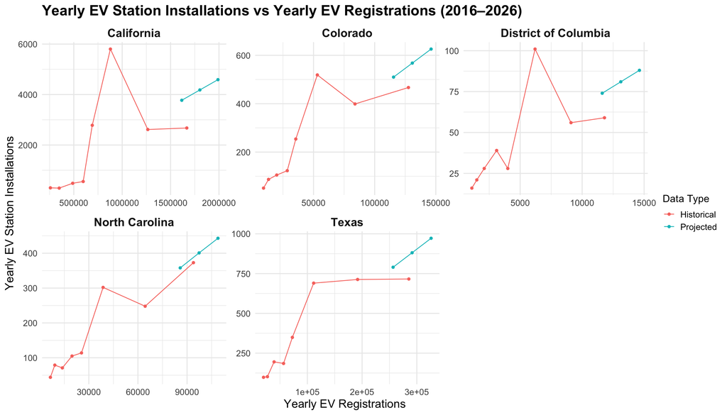

```r
#Preparing historical data for plotting
Historical_Data <- Station_vs_EV %>%
  select(State, Year, Total_EV, Number_of_Stations) %>%
  mutate(Source = "Historical")

#Preparing projected data for plotting
Projected_Data <- Station_Predictions_By_State %>%
  rename(Number_of_Stations = Predicted_Stations) %>%
  mutate(Source = "Projected")

#Combining historical and projected data
Combined_Data_For_Plot <- bind_rows(Historical_Data, Projected_Data)

#Filtering for randomly selected states for representation
Selected_States <- c("California", "District of Columbia", "Texas", "North Carolina", "Colorado")
Filtered_Combined_Data <- Combined_Data_For_Plot %>%
  filter(State %in% Selected_States)

#Creating the filtered plot
ggplot(Filtered_Combined_Data, aes(x = Total_EV, y = Number_of_Stations, color = Source)) +
  geom_point() +
  geom_line() +
  facet_wrap(~ State, scales = "free") +
  labs(
    title = "Yearly EV Station Installations vs Yearly EV Registrations (2016–2026)",
    x = "Yearly EV Registrations",
    y = "Yearly EV Station Installations",
    color = "Data Type"
  ) +
  theme_minimal(base_size = 14) +
  theme(
    strip.text = element_text(size = 16, face = "bold"),
    plot.title = element_text(size = 20, face = "bold"),
    axis.title = element_text(size = 16),
    axis.text = element_text(size = 12),
    legend.title = element_text(size = 14),
    legend.text = element_text(size = 12))
```

> Analysis: In the randomly chosen states - California, Colarodo, District of Columbia, North Carolina and Texas, the projected yearly number of EV registrations decrease for all states for 2024, but project an increasing trend for 2025 and 2026. The projected number of charging station installations increase each year from 2024 to 2026 for all states except for North Carolina where the projected number of charging station installations decrease in 2024 as compared to 2023, and then show an increasing trend growing in number of installations.

## GitHub Link

Attached below is a link to our project repository in GitHub. We hope you enjoy reading our project as much as we enjoyed working on it!

> Link: https://github.com/PrishaTiwari05/Nataraj.Patankar.Tiwari.Wavre